# ST4234 Data Analysis Project

## 2(e)

### Please note that the Posterior is always in Blue

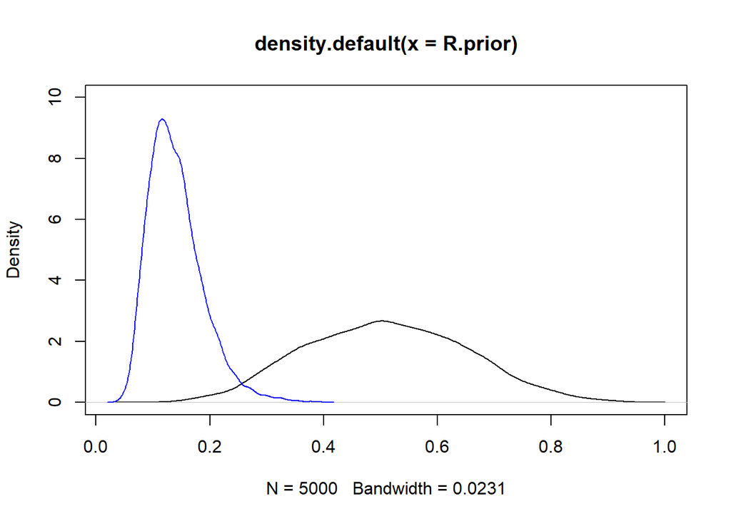

```r
set.seed(0183939)
# Prior samples
tausq.prior <- rinvgamma(5000, shape = a1/2, rate = b1/2)
sigmasq.prior <- rinvgamma(5000, shape = a2/2, rate = b2/2)
R.prior <- tausq.prior / (tausq.prior + sigmasq.prior)

# Posterior samples
R.post <- tausq.mc / (tausq.mc + sigmasq.mc)

# Plot prior and posteriors
plot(density(R.prior), ylim = c(0, 10))
lines(density(R.post), col = "blue")
```

$\tau^2$ is a measure of between-group variance whereas $\sigma^2$ is a measure of within-group variance. Therefore, $R = \frac{\tau^2}{\tau^2 + \sigma^2}$ is a measure of the ratio between-group variance and the overall variance.

As seen in the graphs above, our prior belief for the distribution of $R$ is much further to the right (i.e. larger values) than our posterior distribution. Additionally, the prior has much more spread than the posterior which is more peaked and has smaller variability.

What this means is that the ratio of between-group variance to overall variance is lower, and has less variability, than originally believed. This would suggest that that 8 schools are not as different as initially thought.

## 2(f)

### Please note that the Theta means are in Blue

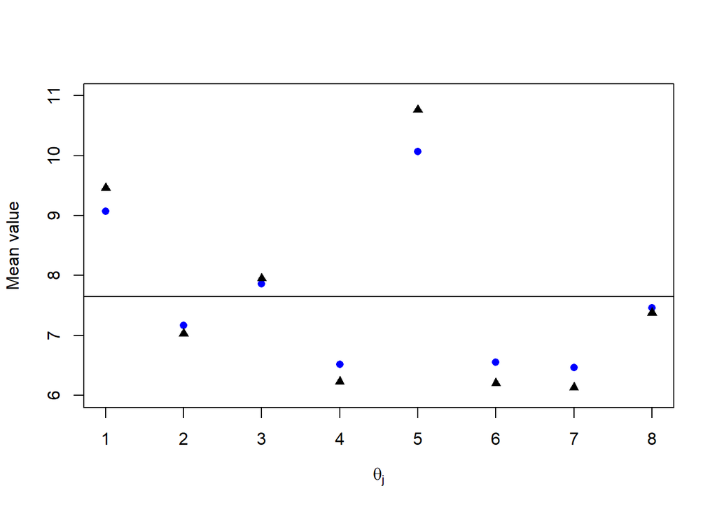

```r
set.seed(0183939)
theta.means <- apply(theta.mc, 2, mean)
plot(1:8, theta.means, col="blue", pch = 16, cex = 1, ylim = c(6, 11),
     xlab = expression(theta[j]), ylab = "Mean value")
points(1:8, y.bar, pch = 17, cex = 1)

abline(h = mean(y.bar))
```

```r
# Note that the overall mean is 7.64589
mean(y.bar)
```

```
## [1] 7.64589
```

The horizontal line shows that overall mean of the samples (i.e. $\bar{\mathbf{y}}$).

The relationship seen is that shrinkage occurs for each of the sample means whereby the posterior is closer to the overall mean (7.6458903), than the original sample mean. This is expected from a bayesian result as it is a the means of the $\theta_j$’s are compromise estimates.

Overall, the shrinkage apprears to be smaller in effect for sample means that were already close to the overall mean, and larger in effect for sample means that were far from the overall mean.